# ASSR_beta

Stefan Wiens & Malina Szychowska

2020-10-12

```r
DSIV_s1=read.csv(file.path(dir_res, paste0("data_audio_signal_noise_ASSR_study1_beta.tsv")), sep="\t",header=TRUE, dec=".")
DSIV_s2=read.csv(file.path(dir_res, paste0("data_audio_signal_noise_ASSR_study2_beta.tsv")), sep="\t",header=TRUE, dec=".")
DSV=read.csv(file.path(dir_res, paste0("data_audio_signal_noise_ASSR2_beta.tsv")), sep="\t",header=TRUE, dec=".")
```

```r
if (any(as.numeric(table(DSIV_s1$fp))!=1)){
  stop("Subject numbers are not unique!")
}

if (any(as.numeric(table(DSIV_s2$fp))!=1)){
  stop("Subject numbers are not unique!")
}

if (any(as.numeric(table(DSV$fp))!=1)){
  stop("Subject numbers are not unique!")
  }
```

```r
# Amp S-N raw

# ASSR Study 1
# the numbers 1 to 4 refer to different blocks

DSIV_s1$AmpSmNlo = rowMeans(cbind(DSIV_s1$AmpSmNlo1,DSIV_s1$AmpSmNlo2,DSIV_s1$AmpSmNlo3,DSIV_s1$AmpSmNlo4))
DSIV_s1$AmpSmNhi = rowMeans(cbind(DSIV_s1$AmpSmNhi1,DSIV_s1$AmpSmNhi2,DSIV_s1$AmpSmNhi3,DSIV_s1$AmpSmNhi4))

# ASSR Study 2
# the numbers 1 to 4 refer to different blocks
DSIV_s2$AmpSmNno = rowMeans(cbind(DSIV_s2$AmpSmNno1,DSIV_s2$AmpSmNno2,DSIV_s2$AmpSmNno3,DSIV_s2$AmpSmNno4))
DSIV_s2$AmpSmNlo = rowMeans(cbind(DSIV_s2$AmpSmNlo1,DSIV_s2$AmpSmNlo2,DSIV_s2$AmpSmNlo3,DSIV_s2$AmpSmNlo4))
DSIV_s2$AmpSmNhi = rowMeans(cbind(DSIV_s2$AmpSmNhi1,DSIV_s2$AmpSmNhi2,DSIV_s2$AmpSmNhi3,DSIV_s2$AmpSmNhi4))
DSIV_s2$AmpSmNvh = rowMeans(cbind(DSIV_s2$AmpSmNvh1,DSIV_s2$AmpSmNvh2,DSIV_s2$AmpSmNvh3,DSIV_s2$AmpSmNvh4))

# ASSR2
# the numbers 1 to 2 refer to different blocks
DSV$AmpSmNno20Hz = rowMeans(cbind(DSV$AmpSmNno20_1,DSV$AmpSmNno20_2))
DSV$AmpSmNno40Hz = rowMeans(cbind(DSV$AmpSmNno40_1,DSV$AmpSmNno40_2))
DSV$AmpSmNno80Hz = rowMeans(cbind(DSV$AmpSmNno80_1,DSV$AmpSmNno80_2))
DSV$AmpSmNlo20Hz = rowMeans(cbind(DSV$AmpSmNlo20_1,DSV$AmpSmNlo20_2))
DSV$AmpSmNlo40Hz = rowMeans(cbind(DSV$AmpSmNlo40_1,DSV$AmpSmNlo40_2))
DSV$AmpSmNlo80Hz = rowMeans(cbind(DSV$AmpSmNlo80_1,DSV$AmpSmNlo80_2))
DSV$AmpSmNhi20Hz = rowMeans(cbind(DSV$AmpSmNhi20_1,DSV$AmpSmNhi20_2))
DSV$AmpSmNhi40Hz = rowMeans(cbind(DSV$AmpSmNhi40_1,DSV$AmpSmNhi40_2))
DSV$AmpSmNhi80Hz = rowMeans(cbind(DSV$AmpSmNhi80_1,DSV$AmpSmNhi80_2))

#
# # Amp S raw
# D$AmpSno20Hz = rowMeans(cbind(D$AmpSno20_1,D$AmpSno20_2))
# D$AmpSno40Hz = rowMeans(cbind(D$AmpSno40_1,D$AmpSno40_2))
# D$AmpSno80Hz = rowMeans(cbind(D$AmpSno80_1,D$AmpSno80_2))
# D$AmpSlo20Hz = rowMeans(cbind(D$AmpSlo20_1,D$AmpSlo20_2))
# D$AmpSlo40Hz = rowMeans(cbind(D$AmpSlo40_1,D$AmpSlo40_2))
# D$AmpSlo80Hz = rowMeans(cbind(D$AmpSlo80_1,D$AmpSlo80_2))
# D$AmpShi20Hz = rowMeans(cbind(D$AmpShi20_1,D$AmpShi20_2))
# D$AmpShi40Hz = rowMeans(cbind(D$AmpShi40_1,D$AmpShi40_2))
# D$AmpShi80Hz = rowMeans(cbind(D$AmpShi80_1,D$AmpShi80_2))
#
# # Amp N raw
# D$AmpNno20Hz = rowMeans(cbind(D$AmpNno20_1,D$AmpNno20_2))
# D$AmpNno40Hz = rowMeans(cbind(D$AmpNno40_1,D$AmpNno40_2))
# D$AmpNno80Hz = rowMeans(cbind(D$AmpNno80_1,D$AmpNno80_2))
# D$AmpNlo20Hz = rowMeans(cbind(D$AmpNlo20_1,D$AmpNlo20_2))
# D$AmpNlo40Hz = rowMeans(cbind(D$AmpNlo40_1,D$AmpNlo40_2))
# D$AmpNlo80Hz = rowMeans(cbind(D$AmpNlo80_1,D$AmpNlo80_2))
# D$AmpNhi20Hz = rowMeans(cbind(D$AmpNhi20_1,D$AmpNhi20_2))
# D$AmpNhi40Hz = rowMeans(cbind(D$AmpNhi40_1,D$AmpNhi40_2))
# D$AmpNhi80Hz = rowMeans(cbind(D$AmpNhi80_1,D$AmpNhi80_2))
#
# # Amp SNR raw
# D$AmpSNRno20Hz = rowMeans(cbind(D$AmpSNRno20_1,D$AmpSNRno20_2))
# D$AmpSNRno40Hz = rowMeans(cbind(D$AmpSNRno40_1,D$AmpSNRno40_2))
# D$AmpSNRno80Hz = rowMeans(cbind(D$AmpSNRno80_1,D$AmpSNRno80_2))
# D$AmpSNRlo20Hz = rowMeans(cbind(D$AmpSNRlo20_1,D$AmpSNRlo20_2))
# D$AmpSNRlo40Hz = rowMeans(cbind(D$AmpSNRlo40_1,D$AmpSNRlo40_2))
# D$AmpSNRlo80Hz = rowMeans(cbind(D$AmpSNRlo80_1,D$AmpSNRlo80_2))
# D$AmpSNRhi20Hz = rowMeans(cbind(D$AmpSNRhi20_1,D$AmpSNRhi20_2))
# D$AmpSNRhi40Hz = rowMeans(cbind(D$AmpSNRhi40_1,D$AmpSNRhi40_2))
# D$AmpSNRhi80Hz = rowMeans(cbind(D$AmpSNRhi80_1,D$AmpSNRhi80_2))
```

```r
# ITC S-N raw

# ASSR Study 1
# the numbers 1 to 4 refer to different blocks

DSIV_s1$ItcSmNlo = rowMeans(cbind(DSIV_s1$ItcSmNlo1,DSIV_s1$ItcSmNlo2,DSIV_s1$ItcSmNlo3,DSIV_s1$ItcSmNlo4))
DSIV_s1$ItcSmNhi = rowMeans(cbind(DSIV_s1$ItcSmNhi1,DSIV_s1$ItcSmNhi2,DSIV_s1$ItcSmNhi3,DSIV_s1$ItcSmNhi4))

# ASSR Study 2
# the numbers 1 to 4 refer to different blocks
DSIV_s2$ItcSmNno = rowMeans(cbind(DSIV_s2$ItcSmNno1,DSIV_s2$ItcSmNno2,DSIV_s2$ItcSmNno3,DSIV_s2$ItcSmNno4))
DSIV_s2$ItcSmNlo = rowMeans(cbind(DSIV_s2$ItcSmNlo1,DSIV_s2$ItcSmNlo2,DSIV_s2$ItcSmNlo3,DSIV_s2$ItcSmNlo4))
DSIV_s2$ItcSmNhi = rowMeans(cbind(DSIV_s2$ItcSmNhi1,DSIV_s2$ItcSmNhi2,DSIV_s2$ItcSmNhi3,DSIV_s2$ItcSmNhi4))
DSIV_s2$ItcSmNvh = rowMeans(cbind(DSIV_s2$ItcSmNvh1,DSIV_s2$ItcSmNvh2,DSIV_s2$ItcSmNvh3,DSIV_s2$ItcSmNvh4))

# ASSR2
# the numbers 1 to 2 refer to different blocks
DSV$ItcSmNno20Hz = rowMeans(cbind(DSV$ItcSmNno20_1,DSV$ItcSmNno20_2))
DSV$ItcSmNno40Hz = rowMeans(cbind(DSV$ItcSmNno40_1,DSV$ItcSmNno40_2))
DSV$ItcSmNno80Hz = rowMeans(cbind(DSV$ItcSmNno80_1,DSV$ItcSmNno80_2))
DSV$ItcSmNlo20Hz = rowMeans(cbind(DSV$ItcSmNlo20_1,DSV$ItcSmNlo20_2))
DSV$ItcSmNlo40Hz = rowMeans(cbind(DSV$ItcSmNlo40_1,DSV$ItcSmNlo40_2))
DSV$ItcSmNlo80Hz = rowMeans(cbind(DSV$ItcSmNlo80_1,DSV$ItcSmNlo80_2))
DSV$ItcSmNhi20Hz = rowMeans(cbind(DSV$ItcSmNhi20_1,DSV$ItcSmNhi20_2))
DSV$ItcSmNhi40Hz = rowMeans(cbind(DSV$ItcSmNhi40_1,DSV$ItcSmNhi40_2))
DSV$ItcSmNhi80Hz = rowMeans(cbind(DSV$ItcSmNhi80_1,DSV$ItcSmNhi80_2))


# # the numbers 1 to 2 refer to different blocks
#
# # ITC S-N raw
# D$ItcSmNno20Hz = rowMeans(cbind(D$ItcSmNno20_1,D$ItcSmNno20_2))
# D$ItcSmNno40Hz = rowMeans(cbind(D$ItcSmNno40_1,D$ItcSmNno40_2))
# D$ItcSmNno80Hz = rowMeans(cbind(D$ItcSmNno80_1,D$ItcSmNno80_2))
# D$ItcSmNlo20Hz = rowMeans(cbind(D$ItcSmNlo20_1,D$ItcSmNlo20_2))
# D$ItcSmNlo40Hz = rowMeans(cbind(D$ItcSmNlo40_1,D$ItcSmNlo40_2))
# D$ItcSmNlo80Hz = rowMeans(cbind(D$ItcSmNlo80_1,D$ItcSmNlo80_2))
# D$ItcSmNhi20Hz = rowMeans(cbind(D$ItcSmNhi20_1,D$ItcSmNhi20_2))
# D$ItcSmNhi40Hz = rowMeans(cbind(D$ItcSmNhi40_1,D$ItcSmNhi40_2))
# D$ItcSmNhi80Hz = rowMeans(cbind(D$ItcSmNhi80_1,D$ItcSmNhi80_2))
#
# # ITC S raw
# D$ItcSno20Hz = rowMeans(cbind(D$ItcSno20_1,D$ItcSno20_2))
# D$ItcSno40Hz = rowMeans(cbind(D$ItcSno40_1,D$ItcSno40_2))
# D$ItcSno80Hz = rowMeans(cbind(D$ItcSno80_1,D$ItcSno80_2))
# D$ItcSlo20Hz = rowMeans(cbind(D$ItcSlo20_1,D$ItcSlo20_2))
# D$ItcSlo40Hz = rowMeans(cbind(D$ItcSlo40_1,D$ItcSlo40_2))
# D$ItcSlo80Hz = rowMeans(cbind(D$ItcSlo80_1,D$ItcSlo80_2))
# D$ItcShi20Hz = rowMeans(cbind(D$ItcShi20_1,D$ItcShi20_2))
# D$ItcShi40Hz = rowMeans(cbind(D$ItcShi40_1,D$ItcShi40_2))
# D$ItcShi80Hz = rowMeans(cbind(D$ItcShi80_1,D$ItcShi80_2))
#
# # ITC N raw
# D$ItcNno20Hz = rowMeans(cbind(D$ItcNno20_1,D$ItcNno20_2))
# D$ItcNno40Hz = rowMeans(cbind(D$ItcNno40_1,D$ItcNno40_2))
# D$ItcNno80Hz = rowMeans(cbind(D$ItcNno80_1,D$ItcNno80_2))
# D$ItcNlo20Hz = rowMeans(cbind(D$ItcNlo20_1,D$ItcNlo20_2))
# D$ItcNlo40Hz = rowMeans(cbind(D$ItcNlo40_1,D$ItcNlo40_2))
# D$ItcNlo80Hz = rowMeans(cbind(D$ItcNlo80_1,D$ItcNlo80_2))
# D$ItcNhi20Hz = rowMeans(cbind(D$ItcNhi20_1,D$ItcNhi20_2))
# D$ItcNhi40Hz = rowMeans(cbind(D$ItcNhi40_1,D$ItcNhi40_2))
# D$ItcNhi80Hz = rowMeans(cbind(D$ItcNhi80_1,D$ItcNhi80_2))
#
# # ITC SNR raw
# D$ItcSNRno20Hz = rowMeans(cbind(D$ItcSNRno20_1,D$ItcSNRno20_2))
# D$ItcSNRno40Hz = rowMeans(cbind(D$ItcSNRno40_1,D$ItcSNRno40_2))
# D$ItcSNRno80Hz = rowMeans(cbind(D$ItcSNRno80_1,D$ItcSNRno80_2))
# D$ItcSNRlo20Hz = rowMeans(cbind(D$ItcSNRlo20_1,D$ItcSNRlo20_2))
# D$ItcSNRlo40Hz = rowMeans(cbind(D$ItcSNRlo40_1,D$ItcSNRlo40_2))
# D$ItcSNRlo80Hz = rowMeans(cbind(D$ItcSNRlo80_1,D$ItcSNRlo80_2))
# D$ItcSNRhi20Hz = rowMeans(cbind(D$ItcSNRhi20_1,D$ItcSNRhi20_2))
# D$ItcSNRhi40Hz = rowMeans(cbind(D$ItcSNRhi40_1,D$ItcSNRhi40_2))
# D$ItcSNRhi80Hz = rowMeans(cbind(D$ItcSNRhi80_1,D$ItcSNRhi80_2))
```

## Means for beta oscillations

### Ampl SmN

Amplitude signal minus noise (SmN)

#### plots

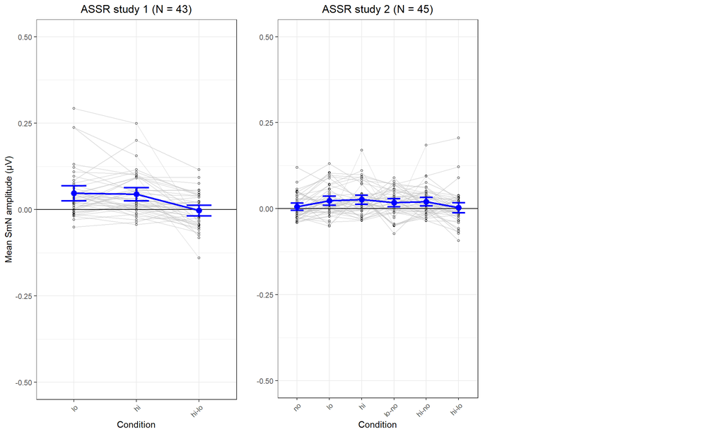

```r
iv = "AmpSmN"
Dtmp = getdiffs_SIV_s1(DSIV_s1, iv = iv)
myylim = c(-0.5, 0.5)#max(Dtmp))
Dtmp = Dtmp[,c(3:5)]#[,c(10:27)]
Dtmp = cbind(DSIV_s1$fp, Dtmp)
colnames(Dtmp)[1] =  c('fp', 'low', 'high', 'high-low')

Dtmp2 = getdiffs_SIV_s2(DSIV_s2, iv = iv)
myylim = c(-0.5, 0.5)#max(Dtmp2))
Dtmp2 = Dtmp2[,c(4:9)]#[,c(10:27)]
Dtmp2 = cbind(DSIV_s2$fp, Dtmp2)
colnames(Dtmp2)[1] =  c('fp', 'no', 'low', 'high', 'low-no','high-no','high-low')

bp1a = plotoverlay(dm = Dtmp,lbl = paste0("ASSR study 1"), dvy = "Mean SmN amplitude (µV)", myylim)
bp1b = plotoverlay(dm = Dtmp2,lbl = paste0("ASSR study 2"), dvy = "", myylim)

grid.arrange(bp1a, bp1b, ncol = 3)
```

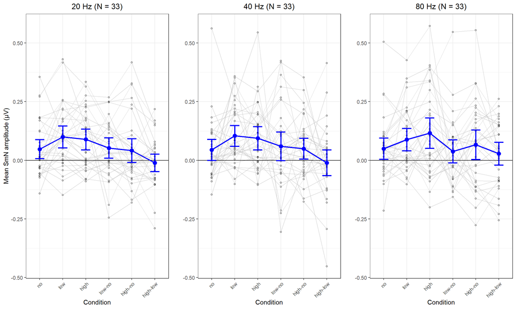

```r
bp1 = arrangeGrob(bp1a, bp1b, ncol = 2)
ggsave(file.path(dir_fig,"figure_amp_beta_ASSRStudy1and2.jpg"), bp1, dpi = 600, width = 5, height = 4)
ggsave(file.path(dir_fig,"figure_amp_beta_ASSRStudy1and2.pdf"), bp1, dpi = 600, width = 5, height = 4)



Dtmp3 = getdiffs_SV(DSV, iv = iv)
myylim = c(min(Dtmp3), max(Dtmp3))
Dtmp3 = Dtmp3[,c(10:27)]
Dtmp3 = cbind(DSV$fp, Dtmp3)

Dtmp3a = Dtmp3[,c(1,2:7)]
colnames(Dtmp3a) = c('fp', 'no', 'low', 'high', 'low-no', 'high-no', 'high-low')
bp3a = plotoverlay(dm = Dtmp3a,lbl = paste0("20 Hz"), dvy = "Mean SmN amplitude (µV)", myylim)
Dtmp3b = Dtmp3[,c(1,8:13)]
colnames(Dtmp3b) = c('fp', 'no', 'low', 'high', 'low-no', 'high-no', 'high-low')
bp3b = plotoverlay(dm = Dtmp3b,lbl = paste0("40 Hz"), dvy = "", myylim)
Dtmp3c = Dtmp3[,c(1,14:19)]
colnames(Dtmp3c) = c('fp', 'no', 'low', 'high', 'low-no', 'high-no', 'high-low')
bp3c = plotoverlay(dm = Dtmp3c,lbl = paste0("80 Hz"), dvy = "", myylim)
grid.arrange(bp3a, bp3b, bp3c, ncol = 3)
```

```r
bp3 = arrangeGrob(bp3a, bp3b, bp3c, ncol = 3)

ggsave(file.path(dir_fig,"figure_amp_beta_ASSR2.jpg"), bp3, dpi = 600, width = 7, height = 4)
ggsave(file.path(dir_fig,"figure_amp_beta_ASSR2.pdf"), bp3, dpi = 600, width = 7, height = 4)
Dtmp_amp = Dtmp # save for later
Dtmp2_amp = Dtmp2 # save for later
Dtmp3_amp = Dtmp3 # save for later
colnames(Dtmp3_amp)[1] = "fp"
```

#### tables

```r
iv = "AmpSmN"
Dtmp = getdiffs_SIV_s1(DSIV_s1, iv = iv)
Dtmp = tableCIs(Dtmp[,-c(1:2)])
Dtmp %>%
  kable(digits = 3, caption = "Study IV s1") %>%
  kable_styling(bootstrap_options = c("striped", "hover", "condensed"),
                full_width = F, position = 'left')
```

Study IV s1

| Variable | Mean | LL | UL | N |
| --- | --- | --- | --- | --- |
| lo | 0.047 | 0.026 | 0.069 | 43 |
| hi | 0.045 | 0.026 | 0.064 | 43 |
| hi-lo | -0.003 | -0.018 | 0.013 | 43 |

```r
Dtmp2 = getdiffs_SIV_s2(DSIV_s2, iv = iv)
Dtmp2 = tableCIs(Dtmp2[,-c(1:3)])
Dtmp2 %>%
  kable(digits = 3, caption = "Study IV s2") %>%
  kable_styling(bootstrap_options = c("striped", "hover", "condensed"),
                full_width = F, position = 'left')
```

Study IV s2

| Variable | Mean | LL | UL | N |
| --- | --- | --- | --- | --- |
| no | 0.006 | -0.004 | 0.017 | 45 |
| lo | 0.023 | 0.010 | 0.036 | 45 |
| hi | 0.026 | 0.013 | 0.040 | 45 |
| lo-no | 0.017 | 0.005 | 0.029 | 45 |
| hi-no | 0.020 | 0.008 | 0.033 | 45 |
| hi-lo | 0.003 | -0.012 | 0.018 | 45 |

```r
Dtmp3 = getdiffs_SV(DSV, iv = iv)
Dtmp3 = tableCIs(Dtmp3[,-c(1:9)])
Dtmp3 %>%
  kable(digits = 3, caption = "Study V") %>%
  kable_styling(bootstrap_options = c("striped", "hover", "condensed"),
                full_width = F, position = 'left')
```

Study V

| Variable | Mean | LL | UL | N |
| --- | --- | --- | --- | --- |
| no20Hz | 0.048 | 0.007 | 0.088 | 33 |
| lo20Hz | 0.100 | 0.053 | 0.147 | 33 |
| hi20Hz | 0.089 | 0.045 | 0.133 | 33 |
| lo-no20Hz | 0.052 | 0.009 | 0.096 | 33 |
| hi-no20Hz | 0.041 | -0.009 | 0.092 | 33 |
| hi-lo20Hz | -0.011 | -0.048 | 0.026 | 33 |
| no40Hz | 0.044 | -0.001 | 0.089 | 33 |
| lo40Hz | 0.104 | 0.060 | 0.148 | 33 |
| hi40Hz | 0.094 | 0.045 | 0.143 | 33 |
| lo-no40Hz | 0.060 | -0.001 | 0.121 | 33 |
| hi-no40Hz | 0.050 | 0.005 | 0.094 | 33 |
| hi-lo40Hz | -0.010 | -0.065 | 0.044 | 33 |
| no80Hz | 0.050 | 0.004 | 0.095 | 33 |
| lo80Hz | 0.088 | 0.040 | 0.136 | 33 |
| hi80Hz | 0.116 | 0.051 | 0.181 | 33 |
| lo-no80Hz | 0.038 | -0.011 | 0.087 | 33 |
| hi-no80Hz | 0.066 | 0.004 | 0.129 | 33 |
| hi-lo80Hz | 0.028 | -0.021 | 0.076 | 33 |

### ITC SmN

Intertrial coherence signal minus noise (SmN)

#### plots

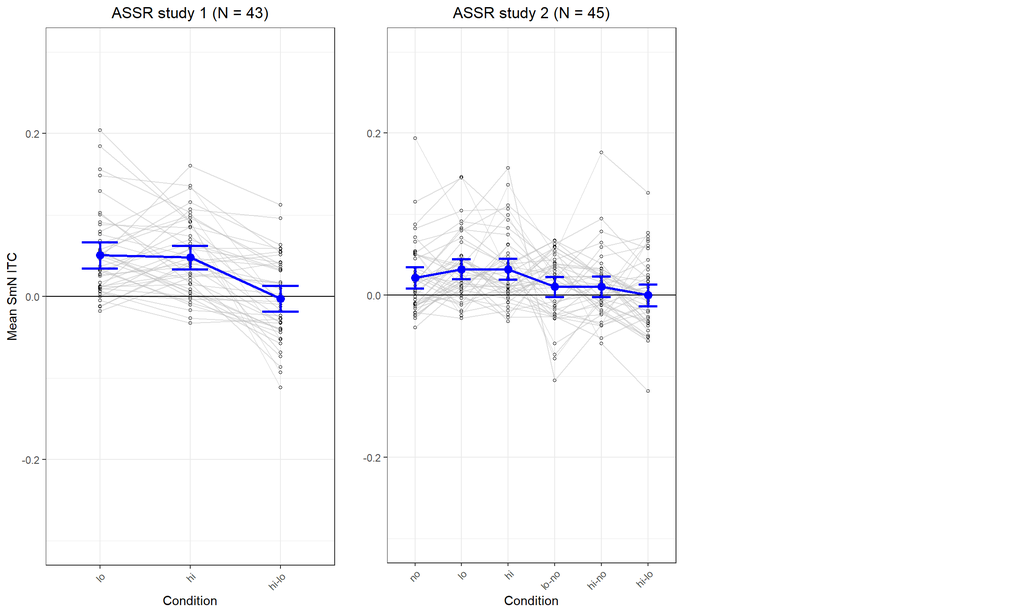

```r
iv = "ItcSmN"
Dtmp = getdiffs_SIV_s1(DSIV_s1, iv = iv)
myylim = c(-0.3, 0.3)#max(Dtmp))
Dtmp = Dtmp[,c(3:5)]#[,c(10:27)]
Dtmp = cbind(DSIV_s1$fp, Dtmp)
colnames(Dtmp)[1] =  c('fp', 'low', 'high', 'high-low')

Dtmp2 = getdiffs_SIV_s2(DSIV_s2, iv = iv)
myylim = c(-0.3, 0.3)#max(Dtmp2))
Dtmp2 = Dtmp2[,c(4:9)]#[,c(10:27)]
Dtmp2 = cbind(DSIV_s2$fp, Dtmp2)
colnames(Dtmp2)[1] =  c('fp', 'no', 'low', 'high', 'low-no','high-no','high-low')

bp1a = plotoverlay(dm = Dtmp,lbl = paste0("ASSR study 1"), dvy = "Mean SmN ITC", myylim)
bp1b = plotoverlay(dm = Dtmp2,lbl = paste0("ASSR study 2"), dvy = "", myylim)

grid.arrange(bp1a, bp1b, ncol = 3)
```

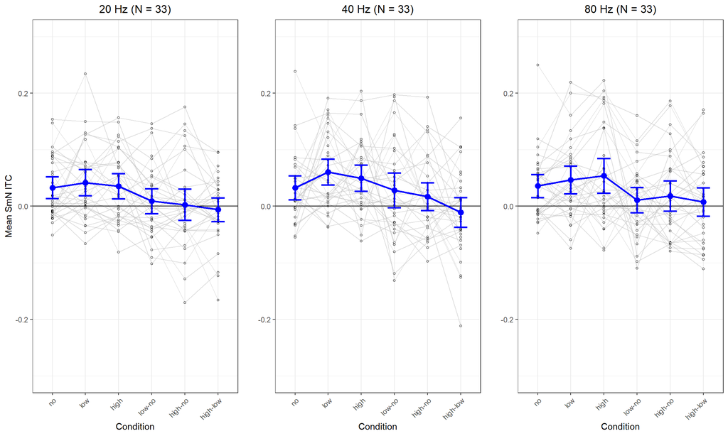

```r
bp1 = arrangeGrob(bp1a, bp1b, ncol = 2)
ggsave(file.path(dir_fig,"figure_itc_beta_ASSRStudy1and2.jpg"), bp1, dpi = 600, width = 5, height = 4)
ggsave(file.path(dir_fig,"figure_itc_beta_ASSRStudy1and2.pdf"), bp1, dpi = 600, width = 5, height = 4)



Dtmp3 = getdiffs_SV(DSV, iv = iv)
myylim = c(-0.3, 0.3)
Dtmp3 = Dtmp3[,c(10:27)]
Dtmp3 = cbind(DSV$fp, Dtmp3)

Dtmp3a = Dtmp3[,c(1,2:7)]
colnames(Dtmp3a) = c('fp', 'no', 'low', 'high', 'low-no', 'high-no', 'high-low')
bp3a = plotoverlay(dm = Dtmp3a,lbl = paste0("20 Hz"), dvy = "Mean SmN ITC", myylim)
Dtmp3b = Dtmp3[,c(1,8:13)]
colnames(Dtmp3b) = c('fp', 'no', 'low', 'high', 'low-no', 'high-no', 'high-low')
bp3b = plotoverlay(dm = Dtmp3b,lbl = paste0("40 Hz"), dvy = "", myylim)
Dtmp3c = Dtmp3[,c(1,14:19)]
colnames(Dtmp3c) = c('fp', 'no', 'low', 'high', 'low-no', 'high-no', 'high-low')
bp3c = plotoverlay(dm = Dtmp3c,lbl = paste0("80 Hz"), dvy = "", myylim)
grid.arrange(bp3a, bp3b, bp3c, ncol = 3)
```

```r
bp3 = arrangeGrob(bp3a, bp3b, bp3c, ncol = 3)

ggsave(file.path(dir_fig,"figure_itc_beta_ASSR2.jpg"), bp3, dpi = 600, width = 7, height = 4)
ggsave(file.path(dir_fig,"figure_itc_beta_ASSR2.pdf"), bp3, dpi = 600, width = 7, height = 4)
Dtmp_itc = Dtmp # save for later
Dtmp2_itc = Dtmp2 # save for later
Dtmp3_itc = Dtmp3 # save for later
```

#### tables

```r
Dtmp = getdiffs_SIV_s1(DSIV_s1, iv = iv)
Dtmp = tableCIs(Dtmp[,-c(1:2)])
Dtmp %>%
  kable(digits = 3, caption = "Study IV s1") %>%
  kable_styling(bootstrap_options = c("striped", "hover", "condensed"),
                full_width = F, position = 'left')
```

Study IV s1

| Variable | Mean | LL | UL | N |
| --- | --- | --- | --- | --- |
| lo | 0.051 | 0.034 | 0.067 | 43 |
| hi | 0.048 | 0.033 | 0.062 | 43 |
| hi-lo | -0.003 | -0.019 | 0.013 | 43 |

```r
Dtmp2 = getdiffs_SIV_s2(DSIV_s2, iv = iv)
Dtmp2 = tableCIs(Dtmp2[,-c(1:3)])
Dtmp2 %>%
  kable(digits = 3, caption = "Study IV s2") %>%
  kable_styling(bootstrap_options = c("striped", "hover", "condensed"),
                full_width = F, position = 'left')
```

Study IV s2

| Variable | Mean | LL | UL | N |
| --- | --- | --- | --- | --- |
| no | 0.022 | 0.009 | 0.035 | 45 |
| lo | 0.032 | 0.020 | 0.045 | 45 |
| hi | 0.032 | 0.019 | 0.045 | 45 |
| lo-no | 0.010 | -0.002 | 0.023 | 45 |
| hi-no | 0.010 | -0.002 | 0.023 | 45 |
| hi-lo | 0.000 | -0.014 | 0.014 | 45 |

```r
Dtmp3 = getdiffs_SV(DSV, iv = iv)
Dtmp3 = tableCIs(Dtmp3[,-c(1:9)])
Dtmp3 %>%
  kable(digits = 3, caption = "Study V") %>%
  kable_styling(bootstrap_options = c("striped", "hover", "condensed"),
                full_width = F, position = 'left')
```

Study V

| Variable | Mean | LL | UL | N |
| --- | --- | --- | --- | --- |
| no20Hz | 0.033 | 0.013 | 0.052 | 33 |
| lo20Hz | 0.041 | 0.018 | 0.065 | 33 |
| hi20Hz | 0.035 | 0.013 | 0.058 | 33 |
| lo-no20Hz | 0.009 | -0.013 | 0.031 | 33 |
| hi-no20Hz | 0.003 | -0.025 | 0.030 | 33 |
| hi-lo20Hz | -0.006 | -0.027 | 0.014 | 33 |
| no40Hz | 0.033 | 0.011 | 0.054 | 33 |
| lo40Hz | 0.060 | 0.037 | 0.084 | 33 |
| hi40Hz | 0.049 | 0.026 | 0.073 | 33 |
| lo-no40Hz | 0.028 | -0.003 | 0.058 | 33 |
| hi-no40Hz | 0.017 | -0.008 | 0.041 | 33 |
| hi-lo40Hz | -0.011 | -0.037 | 0.015 | 33 |
| no80Hz | 0.036 | 0.015 | 0.056 | 33 |
| lo80Hz | 0.046 | 0.022 | 0.071 | 33 |
| hi80Hz | 0.054 | 0.023 | 0.085 | 33 |
| lo-no80Hz | 0.011 | -0.012 | 0.033 | 33 |
| hi-no80Hz | 0.018 | -0.009 | 0.045 | 33 |
| hi-lo80Hz | 0.007 | -0.018 | 0.033 | 33 |

## Study V: 20-, 40-, and 80-Hz ASSRs

Study V included 3 different modulation frequencies: 20, 40, and 80 Hz. Below are the results for beta analyses for each frequency separately and averaged across all frequencies

```r
# ASSR2 20 Hz
Dtmpa3_20 = subset(Dtmp3_amp,
               select=c(fp, no20Hz, lo20Hz, hi20Hz))
colnames(Dtmpa3_20) = c('fp', 'AmpSmNno', 'AmpSmNlo', 'AmpSmNhi')
Dtmpi3_20 = subset(Dtmp3_itc,
               select=c(no20Hz, lo20Hz, hi20Hz))
colnames(Dtmpi3_20) = c('ItcSmNno', 'ItcSmNlo', 'ItcSmNhi')
Dtmp3_20 = cbind(Dtmpa3_20, Dtmpi3_20)
Dtmp3_20$freq = 20

# ASSR2 40 Hz
Dtmpa3_40 = subset(Dtmp3_amp,
               select=c(fp, no40Hz, lo40Hz, hi40Hz))
colnames(Dtmpa3_40) = c('fp', 'AmpSmNno', 'AmpSmNlo', 'AmpSmNhi')
Dtmpi3_40 = subset(Dtmp3_itc,
               select=c(no40Hz, lo40Hz, hi40Hz))
colnames(Dtmpi3_40) = c('ItcSmNno', 'ItcSmNlo', 'ItcSmNhi')
Dtmp3_40 = cbind(Dtmpa3_40, Dtmpi3_40)
Dtmp3_40$freq = 40

# ASSR2 40 Hz
Dtmpa3_80 = subset(Dtmp3_amp,
               select=c(fp, no80Hz, lo80Hz, hi80Hz))
colnames(Dtmpa3_80) = c('fp', 'AmpSmNno', 'AmpSmNlo', 'AmpSmNhi')
Dtmpi3_80 = subset(Dtmp3_itc,
               select=c(no80Hz, lo80Hz, hi80Hz))
colnames(Dtmpi3_80) = c('ItcSmNno', 'ItcSmNlo', 'ItcSmNhi')
Dtmp3_80 = cbind(Dtmpa3_80, Dtmpi3_80)
Dtmp3_80$freq = 80

# combined amp
Davg_no = subset(Dtmp3_amp,
               select=c(no20Hz, no40Hz, no80Hz))

Davg_lo = subset(Dtmp3_amp,
               select=c(lo20Hz, lo40Hz, lo80Hz))

Davg_hi = subset(Dtmp3_amp,
               select=c(hi20Hz, hi40Hz, hi80Hz))

Davg = data.frame(Dtmp3_amp['fp'])
Davg$no = rowMeans(Davg_no)
Davg$lo = rowMeans(Davg_lo)
Davg$hi = rowMeans(Davg_hi)
colnames(Davg) = c('fp', 'AmpSmNno', 'AmpSmNlo', 'AmpSmNhi')


# combined itc
Davgi_no = subset(Dtmp3_itc,
               select=c(no20Hz, no40Hz, no80Hz))

Davgi_lo = subset(Dtmp3_itc,
               select=c(lo20Hz, lo40Hz, lo80Hz))

Davgi_hi = subset(Dtmp3_itc,
               select=c(hi20Hz, hi40Hz, hi80Hz))

Davgi = data.frame(Dtmp3_amp['fp'])
Davgi$no = rowMeans(Davgi_no)
Davgi$lo = rowMeans(Davgi_lo)
Davgi$hi = rowMeans(Davgi_hi)
colnames(Davgi) = c('fp', 'ItcSmNno', 'ItcSmNlo', 'ItcSmNhi')
```

### load effect: high minus low

High load is used as the upper limit of the H1 model.  
H1 model:  
LL = 0  
UL = high load  
In the table, LL and UL refer to the 95% CIs of the means (and not to the LL and UL of the H1 models).

```r
DBF10 = numeric()

# create matrix with measure, study, n, mean high load,
# diff hiMlo, LL 95%CI, UL 95%CI, BF10 hiMlo, BF01 hiMlo,
LL = 0

# amp
# 20 Hz
UL = mean(Dtmp3_20$AmpSmNhi)
tmp = Dtmp3_20$AmpSmNhi-Dtmp3_20$AmpSmNlo
DBF10 = rbind(DBF10, c('20 Hz','Amp', nrow(Dtmp3_20), UL,
                       mean(tmp), ci(tmp), 1/BFfitH1(LL = 0, UL, tmp), BFfitH1(LL = 0, UL, tmp)))

# 40 Hz
UL = mean(Dtmp3_40$AmpSmNhi)
tmp = Dtmp3_40$AmpSmNhi-Dtmp3_40$AmpSmNlo
DBF10 = rbind(DBF10, c('40 Hz','Amp', nrow(Dtmp3_40), UL,
                       mean(tmp), ci(tmp), 1/BFfitH1(LL = 0, UL, tmp), BFfitH1(LL = 0, UL, tmp)))

# 80 Hz
UL = mean(Dtmp3_80$AmpSmNhi)
tmp = Dtmp3_80$AmpSmNhi-Dtmp3_80$AmpSmNlo
DBF10 = rbind(DBF10, c('80 Hz', 'Amp', nrow(Dtmp3_80), UL,
                       mean(tmp), ci(tmp), 1/BFfitH1(LL = 0, UL, tmp), BFfitH1(LL = 0, UL, tmp)))

# combined
UL = mean(Davg$AmpSmNhi)
tmp = Davg$AmpSmNhi-Davg$AmpSmNlo
DBF10 = rbind(DBF10, c('Combined','Amp', nrow(Davg), UL,
                       mean(tmp), ci(tmp), 1/BFfitH1(LL = 0, UL, tmp), BFfitH1(LL = 0, UL, tmp)))

# itc
# 20 Hz
UL = mean(Dtmp3_20$ItcSmNhi)
tmp = Dtmp3_20$ItcSmNhi-Dtmp3_20$ItcSmNlo
DBF10 = rbind(DBF10, c('20 Hz','Itc', nrow(Dtmp3_20), UL,
                       mean(tmp), ci(tmp), 1/BFfitH1(LL = 0, UL, tmp), BFfitH1(LL = 0, UL, tmp)))

# 40 Hz
UL = mean(Dtmp3_40$ItcSmNhi)
tmp = Dtmp3_40$ItcSmNhi-Dtmp3_40$ItcSmNlo
DBF10 = rbind(DBF10, c('40 Hz','Itc', nrow(Dtmp3_40), UL,
                       mean(tmp), ci(tmp), 1/BFfitH1(LL = 0, UL, tmp), BFfitH1(LL = 0, UL, tmp)))

# 80 Hz
UL = mean(Dtmp3_80$ItcSmNhi)
tmp = Dtmp3_80$ItcSmNhi-Dtmp3_80$ItcSmNlo
DBF10 = rbind(DBF10, c('80 Hz', 'Itc', nrow(Dtmp3_80), UL,
                       mean(tmp), ci(tmp), 1/BFfitH1(LL = 0, UL, tmp), BFfitH1(LL = 0, UL, tmp)))

# combined
UL = mean(Davgi$ItcSmNhi)
tmp = Davgi$ItcSmNhi-Davgi$ItcSmNlo
DBF10 = rbind(DBF10, c('Combined','Itc', nrow(Davgi), UL,
                       mean(tmp), ci(tmp), 1/BFfitH1(LL = 0, UL, tmp), BFfitH1(LL = 0, UL, tmp)))


DBF10 = as.data.frame(DBF10)
colnames(DBF10)=c('Freq','Measure','N','Mhi',
                  'M-hiMlo','LL-hiMlo','UL-hiMlo','BF10-hiMlo','BF01-hiMlo')

# convert character to numeric
i = 3:9
DBF10[, i] = apply(DBF10[,i],2, function(x) as.numeric(as.character(x)))
DBF10 %>%
  kable(digits = 3,
        col.names = c('Freq','Measure','N','Mean',
                      'Mean','LL', 'UL', 'BF10', 'BF01')) %>%
  kable_styling(bootstrap_options = c("striped", "hover", "condensed"),
                full_width = F, position = 'left') %>%
  add_header_above(c(" " = 3, "high" = 1, "high minus low" = 5)) %>%
  row_spec(c(4,8), bold = T)
```

| Freq | Measure | N | high Mean | high minus low Mean | high minus low LL | high minus low UL | high minus low BF10 | high minus low BF01 |
| --- | --- | --- | --- | --- | --- | --- | --- | --- |
| 20 Hz | Amp | 33 | 0.089 | -0.011 | -0.048 | 0.026 | 0.173 | 5.789 |
| 40 Hz | Amp | 33 | 0.094 | -0.010 | -0.065 | 0.044 | 0.274 | 3.650 |
| 80 Hz | Amp | 33 | 0.116 | 0.028 | -0.021 | 0.076 | 0.911 | 1.098 |
| Combined | Amp | 33 | 0.100 | 0.002 | -0.022 | 0.027 | 0.178 | 5.630 |
| 20 Hz | Itc | 33 | 0.035 | -0.006 | -0.027 | 0.014 | 0.241 | 4.154 |
| 40 Hz | Itc | 33 | 0.049 | -0.011 | -0.037 | 0.015 | 0.191 | 5.230 |
| 80 Hz | Itc | 33 | 0.054 | 0.007 | -0.018 | 0.033 | 0.501 | 1.995 |
| Combined | Itc | 33 | 0.046 | -0.003 | -0.015 | 0.008 | 0.107 | 9.336 |

### task effect: low minus no

Low load is used as the upper limit of the H1 model.  
H1 model:  
LL = 0  
UL = low load  
In the table, LL and UL refer to the 95% CIs of the means (and not to the LL and UL of the H1 models).

```r
# compare low with no load
DBF10 = numeric()

# create matrix with measure, study, n, mean low load,
# diff loMhi, LL 95%CI, UL 95%CI, BF01 loMhi
LL = 0

# amp
# 20 Hz
UL = mean(Dtmp3_20$AmpSmNlo)
tmp = Dtmp3_20$AmpSmNlo-Dtmp3_20$AmpSmNno
DBF10 = rbind(DBF10, c('20 Hz','Amp', nrow(Dtmp3_20), UL,
                       mean(tmp), ci(tmp), 1/BFfitH1(LL = 0, UL, tmp), BFfitH1(LL = 0, UL, tmp)))

# 40 Hz
UL = mean(Dtmp3_40$AmpSmNlo)
tmp = Dtmp3_40$AmpSmNlo-Dtmp3_40$AmpSmNno
DBF10 = rbind(DBF10, c('40 Hz','Amp', nrow(Dtmp3_40), UL,
                       mean(tmp), ci(tmp), 1/BFfitH1(LL = 0, UL, tmp), BFfitH1(LL = 0, UL, tmp)))

# 80 Hz
UL = mean(Dtmp3_80$AmpSmNlo)
tmp = Dtmp3_80$AmpSmNlo-Dtmp3_80$AmpSmNno
DBF10 = rbind(DBF10, c('80 Hz', 'Amp', nrow(Dtmp3_80), UL,
                       mean(tmp), ci(tmp), 1/BFfitH1(LL = 0, UL, tmp), BFfitH1(LL = 0, UL, tmp)))

# combined
UL = mean(Davg$AmpSmNlo)
tmp = Davg$AmpSmNlo-Davg$AmpSmNno
DBF10 = rbind(DBF10, c('Combined','Amp', nrow(Davg), UL,
                       mean(tmp), ci(tmp), 1/BFfitH1(LL = 0, UL, tmp), BFfitH1(LL = 0, UL, tmp)))

# itc
# 20 Hz
UL = mean(Dtmp3_20$ItcSmNlo)
tmp = Dtmp3_20$ItcSmNlo-Dtmp3_20$ItcSmNno
DBF10 = rbind(DBF10, c('20 Hz','Itc', nrow(Dtmp3_20), UL,
                       mean(tmp), ci(tmp), 1/BFfitH1(LL = 0, UL, tmp), BFfitH1(LL = 0, UL, tmp)))

# 40 Hz
UL = mean(Dtmp3_40$ItcSmNlo)
tmp = Dtmp3_40$ItcSmNlo-Dtmp3_40$ItcSmNno
DBF10 = rbind(DBF10, c('40 Hz','Itc', nrow(Dtmp3_40), UL,
                       mean(tmp), ci(tmp), 1/BFfitH1(LL = 0, UL, tmp), BFfitH1(LL = 0, UL, tmp)))

# 80 Hz
UL = mean(Dtmp3_80$ItcSmNlo)
tmp = Dtmp3_80$ItcSmNlo-Dtmp3_80$ItcSmNno
DBF10 = rbind(DBF10, c('80 Hz', 'Itc', nrow(Dtmp3_80), UL,
                       mean(tmp), ci(tmp), 1/BFfitH1(LL = 0, UL, tmp), BFfitH1(LL = 0, UL, tmp)))

# combined
UL = mean(Davgi$ItcSmNlo)
tmp = Davgi$ItcSmNlo-Davgi$ItcSmNno
DBF10 = rbind(DBF10, c('Combined','Itc', nrow(Davgi), UL,
                       mean(tmp), ci(tmp), 1/BFfitH1(LL = 0, UL, tmp), BFfitH1(LL = 0, UL, tmp)))


DBF10 = as.data.frame(DBF10)
colnames(DBF10)=c('Freq','Measure','N','Mlo',
                  'M-loMno','LL-loMno','UL-loMno','BF10-loMno','BF01-loMno')

# convert character to numeric
i = 3:9
DBF10[, i] = apply(DBF10[,i],2, function(x) as.numeric(as.character(x)))
DBF10 %>%
  kable(digits = 3,
        col.names = c('Freq','Measure','N','Mean',
                      'Mean','LL', 'UL', 'BF10', 'BF01')) %>%
  kable_styling(bootstrap_options = c("striped", "hover", "condensed"),
                full_width = F, position = 'left') %>%
  add_header_above(c(" " = 3, "low" = 1, "low minus no" = 5)) %>%
  row_spec(c(4,8), bold = T)
```

| Freq | Measure | N | low Mean | low minus no Mean | low minus no LL | low minus no UL | low minus no BF10 | low minus no BF01 |
| --- | --- | --- | --- | --- | --- | --- | --- | --- |
| 20 Hz | Amp | 33 | 0.100 | 0.052 | 0.009 | 0.096 | 9.129 | 0.110 |
| 40 Hz | Amp | 33 | 0.104 | 0.060 | -0.001 | 0.121 | 4.588 | 0.218 |
| 80 Hz | Amp | 33 | 0.088 | 0.038 | -0.011 | 0.087 | 2.226 | 0.449 |
| Combined | Amp | 33 | 0.097 | 0.050 | 0.012 | 0.088 | 13.452 | 0.074 |
| 20 Hz | Itc | 33 | 0.041 | 0.009 | -0.013 | 0.031 | 0.735 | 1.360 |
| 40 Hz | Itc | 33 | 0.060 | 0.028 | -0.003 | 0.058 | 3.203 | 0.312 |
| 80 Hz | Itc | 33 | 0.046 | 0.011 | -0.012 | 0.033 | 0.812 | 1.232 |
| Combined | Itc | 33 | 0.049 | 0.016 | -0.002 | 0.034 | 2.171 | 0.461 |

### combined effect: high minus no

High load is used as the upper limit of the H1 model.  
H1 model:  
LL = 0  
UL = high load

Note that Study IV s1 is excluded because no load was not administered.

In the table, LL and UL refer to the 95% CIs of the means (and not to the LL and UL of the H1 models).

```r
DBF10 = numeric()

# create matrix with measure, study, n, mean no load,
# diff hiMno, LL 95%CI, UL 95%CI, BF10 hiMno, BF01 hiMno,
# diff hiMlo, LL 95%CI, UL 95%CI, BF10 hiMlo, BF01 hiMlo,
LL = 0

# amp
# 20 Hz
UL = mean(Dtmp3_20$AmpSmNhi)
tmp = Dtmp3_20$AmpSmNhi-Dtmp3_20$AmpSmNno
DBF10 = rbind(DBF10, c('20 Hz','Amp', nrow(Dtmp3_20), UL,
                       mean(tmp), ci(tmp), 1/BFfitH1(LL = 0, UL, tmp), BFfitH1(LL = 0, UL, tmp)))

# 40 Hz
UL = mean(Dtmp3_40$AmpSmNhi)
tmp = Dtmp3_40$AmpSmNhi-Dtmp3_40$AmpSmNno
DBF10 = rbind(DBF10, c('40 Hz','Amp', nrow(Dtmp3_40), UL,
                       mean(tmp), ci(tmp), 1/BFfitH1(LL = 0, UL, tmp), BFfitH1(LL = 0, UL, tmp)))

# 80 Hz
UL = mean(Dtmp3_80$AmpSmNhi)
tmp = Dtmp3_80$AmpSmNhi-Dtmp3_80$AmpSmNno
DBF10 = rbind(DBF10, c('80 Hz', 'Amp', nrow(Dtmp3_80), UL,
                       mean(tmp), ci(tmp), 1/BFfitH1(LL = 0, UL, tmp), BFfitH1(LL = 0, UL, tmp)))

# combined
UL = mean(Davg$AmpSmNhi)
tmp = Davg$AmpSmNhi-Davg$AmpSmNno
DBF10 = rbind(DBF10, c('Combined','Amp', nrow(Davg), UL,
                       mean(tmp), ci(tmp), 1/BFfitH1(LL = 0, UL, tmp), BFfitH1(LL = 0, UL, tmp)))

# itc
# 20 Hz
UL = mean(Dtmp3_20$ItcSmNhi)
tmp = Dtmp3_20$ItcSmNhi-Dtmp3_20$ItcSmNno
DBF10 = rbind(DBF10, c('20 Hz','Itc', nrow(Dtmp3_20), UL,
                       mean(tmp), ci(tmp), 1/BFfitH1(LL = 0, UL, tmp), BFfitH1(LL = 0, UL, tmp)))

# 40 Hz
UL = mean(Dtmp3_40$ItcSmNhi)
tmp = Dtmp3_40$ItcSmNhi-Dtmp3_40$ItcSmNno
DBF10 = rbind(DBF10, c('40 Hz','Itc', nrow(Dtmp3_40), UL,
                       mean(tmp), ci(tmp), 1/BFfitH1(LL = 0, UL, tmp), BFfitH1(LL = 0, UL, tmp)))

# 80 Hz
UL = mean(Dtmp3_80$ItcSmNhi)
tmp = Dtmp3_80$ItcSmNhi-Dtmp3_80$ItcSmNno
DBF10 = rbind(DBF10, c('80 Hz', 'Itc', nrow(Dtmp3_80), UL,
                       mean(tmp), ci(tmp), 1/BFfitH1(LL = 0, UL, tmp), BFfitH1(LL = 0, UL, tmp)))

# combined
UL = mean(Davgi$ItcSmNhi)
tmp = Davgi$ItcSmNhi-Davgi$ItcSmNno
DBF10 = rbind(DBF10, c('Combined','Itc', nrow(Davgi), UL,
                       mean(tmp), ci(tmp), 1/BFfitH1(LL = 0, UL, tmp), BFfitH1(LL = 0, UL, tmp)))


DBF10 = as.data.frame(DBF10)
colnames(DBF10)=c('Freq','Measure','N','Mhi',
                  'M-hiMno','LL-hiMno','UL-hiMno','BF10-hiMno','BF01-hiMno')

# convert character to numeric
i = 3:9
DBF10[, i] = apply(DBF10[,i],2, function(x) as.numeric(as.character(x)))
DBF10 %>%
  kable(digits = 3,
        col.names = c('Freq','Measure','N','Mean',
                      'Mean','LL', 'UL', 'BF10', 'BF01')) %>%
  kable_styling(bootstrap_options = c("striped", "hover", "condensed"),
                full_width = F, position = 'left') %>%
  add_header_above(c(" " = 3, "high" = 1, "high minus no" = 5)) %>%
  row_spec(c(4,8), bold = T)
```

| Freq | Measure | N | high Mean | high minus no Mean | high minus no LL | high minus no UL | high minus no BF10 | high minus no BF01 |
| --- | --- | --- | --- | --- | --- | --- | --- | --- |
| 20 Hz | Amp | 33 | 0.089 | 0.041 | -0.009 | 0.092 | 2.543 | 0.393 |
| 40 Hz | Amp | 33 | 0.094 | 0.050 | 0.005 | 0.094 | 6.579 | 0.152 |
| 80 Hz | Amp | 33 | 0.116 | 0.066 | 0.004 | 0.129 | 5.764 | 0.173 |
| Combined | Amp | 33 | 0.100 | 0.052 | 0.014 | 0.091 | 17.425 | 0.057 |
| 20 Hz | Itc | 33 | 0.035 | 0.003 | -0.025 | 0.030 | 0.559 | 1.790 |
| 40 Hz | Itc | 33 | 0.049 | 0.017 | -0.008 | 0.041 | 1.498 | 0.668 |
| 80 Hz | Itc | 33 | 0.054 | 0.018 | -0.009 | 0.045 | 1.445 | 0.692 |
| Combined | Itc | 33 | 0.046 | 0.013 | -0.006 | 0.031 | 1.171 | 0.854 |

## Combined data from all studies

Study IV s1 (N = 43) in Szychowska & Wiens (2020). This study included **low and high** load.

Study IV s2 (N = 45) in Szychowska & Wiens (2020). This study included **no, low, high, and very high** load.

Study V (N = 33) in Szychowska & Wiens (2020). This study included **no, low, high** load.

### 40-Hz ASSRs

```r
# ASSR Study1
Dtmpa1 = subset(Dtmp_amp,
               select=c(fp, lo, hi))
colnames(Dtmpa1) = c('fp', 'AmpSmNlo', 'AmpSmNhi')
Dtmpi1 = subset(Dtmp_itc,
               select=c(lo, hi))
colnames(Dtmpi1) = c('ItcSmNlo', 'ItcSmNhi')
Dtmp1 = cbind(Dtmpa1, Dtmpi1)
Dtmp1$study = 'Study IV s1'

# ASSR Study2
Dtmpa2 = subset(Dtmp2_amp,
               select=c(fp, no, lo, hi))
colnames(Dtmpa2) = c('fp', 'AmpSmNno', 'AmpSmNlo', 'AmpSmNhi')
Dtmpi2 = subset(Dtmp2_itc,
               select=c(no, lo, hi))
colnames(Dtmpi2) = c('ItcSmNno', 'ItcSmNlo', 'ItcSmNhi')
Dtmp2 = cbind(Dtmpa2, Dtmpi2)
Dtmp2$study = 'Study IV s2'

# ASSR2
Dtmpa3 = subset(Dtmp3_amp,
               select=c(fp, no40Hz, lo40Hz, hi40Hz))
colnames(Dtmpa3) = c('fp', 'AmpSmNno', 'AmpSmNlo', 'AmpSmNhi')
Dtmpi3 = subset(Dtmp3_itc,
               select=c(no40Hz, lo40Hz, hi40Hz))
colnames(Dtmpi3) = c('ItcSmNno', 'ItcSmNlo', 'ItcSmNhi')
Dtmp3 = cbind(Dtmpa3, Dtmpi3)
Dtmp3$study = 'Study V'


Dall = merge(Dtmp1, Dtmp2, all = T)
Dall = merge(Dall, Dtmp3, all = T)

D2and3 = merge(Dtmp2, Dtmp3, all = T)
```

#### load effect: high minus low

High load is used as the upper limit of the H1 model.  
H1 model:  
LL = 0  
UL = high load  
In the table, LL and UL refer to the 95% CIs of the means (and not to the LL and UL of the H1 models).

```r
DBF10 = numeric()

# create matrix with measure, study, n, mean no load,
# diff hiMlo, LL 95%CI, UL 95%CI, BF10 hiMlo, BF01 hiMlo,
LL = 0

# amp
# study 1
UL = mean(Dtmp1$AmpSmNhi)
tmp = Dtmp1$AmpSmNhi-Dtmp1$AmpSmNlo
DBF10 = rbind(DBF10, c('Study IV s1','Amp', nrow(Dtmp1), UL,
                       mean(tmp), ci(tmp), 1/BFfitH1(LL = 0, UL, tmp), BFfitH1(LL = 0, UL, tmp)))

# study 2
UL = mean(Dtmp2$AmpSmNhi)
tmp = Dtmp2$AmpSmNhi-Dtmp2$AmpSmNlo
DBF10 = rbind(DBF10, c('Study IV s2','Amp', nrow(Dtmp2), UL,
                       mean(tmp), ci(tmp), 1/BFfitH1(LL = 0, UL, tmp), BFfitH1(LL = 0, UL, tmp)))

# ASSR2
UL = mean(Dtmp3$AmpSmNhi)
tmp = Dtmp3$AmpSmNhi-Dtmp3$AmpSmNlo
DBF10 = rbind(DBF10, c('Study V', 'Amp', nrow(Dtmp3), UL,
                       mean(tmp), ci(tmp), 1/BFfitH1(LL = 0, UL, tmp), BFfitH1(LL = 0, UL, tmp)))

# combined
UL = mean(Dall$AmpSmNhi)
tmp = Dall$AmpSmNhi-Dall$AmpSmNlo
DBF10 = rbind(DBF10, c('Combined','Amp', nrow(Dall), UL,
                       mean(tmp), ci(tmp), 1/BFfitH1(LL = 0, UL, tmp), BFfitH1(LL = 0, UL, tmp)))

# itc
# study 1
UL = mean(Dtmp1$ItcSmNhi)
tmp = Dtmp1$ItcSmNhi-Dtmp1$ItcSmNlo
DBF10 = rbind(DBF10, c('Study IV s1','Itc', nrow(Dtmp1), UL,
                       mean(tmp), ci(tmp), 1/BFfitH1(LL = 0, UL, tmp), BFfitH1(LL = 0, UL, tmp)))

# study 2
UL = mean(Dtmp2$ItcSmNhi)
tmp = Dtmp2$ItcSmNhi-Dtmp2$ItcSmNlo
DBF10 = rbind(DBF10, c('Study IV s2','Itc', nrow(Dtmp2), UL,
                       mean(tmp), ci(tmp), 1/BFfitH1(LL = 0, UL, tmp), BFfitH1(LL = 0, UL, tmp)))

# ASSR2
UL = mean(Dtmp3$ItcSmNhi)
tmp = Dtmp3$ItcSmNhi-Dtmp3$ItcSmNlo
DBF10 = rbind(DBF10, c('Study V', 'Itc', nrow(Dtmp3), UL,
                       mean(tmp), ci(tmp), 1/BFfitH1(LL = 0, UL, tmp), BFfitH1(LL = 0, UL, tmp)))

# combined
UL = mean(Dall$ItcSmNhi)
tmp = Dall$ItcSmNhi-Dall$ItcSmNlo
DBF10 = rbind(DBF10, c('Combined', 'Itc', nrow(Dall), UL,
                       mean(tmp), ci(tmp), 1/BFfitH1(LL = 0, UL, tmp), BFfitH1(LL = 0, UL, tmp)))


DBF10 = as.data.frame(DBF10)
colnames(DBF10)=c('Study','Measure','N','Mhi',
                  'M-hiMlo','LL-hiMlo','UL-hiMlo','BF10-hiMlo','BF01-hiMlo')

# convert character to numeric
i = 3:9
DBF10[, i] = apply(DBF10[,i],2, function(x) as.numeric(as.character(x)))
DBF10 %>%
  kable(digits = 3,
        col.names = c('Study','Measure','N','Mean',
                      'Mean','LL', 'UL', 'BF10', 'BF01')) %>%
  kable_styling(bootstrap_options = c("striped", "hover", "condensed"),
                full_width = F, position = 'left') %>%
  add_header_above(c(" " = 3, "high" = 1, "high minus low" = 5)) %>%
  row_spec(c(4,8), bold = T)
```

| Study | Measure | N | high Mean | high minus low Mean | high minus low LL | high minus low UL | high minus low BF10 | high minus low BF01 |
| --- | --- | --- | --- | --- | --- | --- | --- | --- |
| Study IV s1 | Amp | 43 | 0.045 | -0.003 | -0.018 | 0.013 | 0.168 | 5.938 |
| Study IV s2 | Amp | 45 | 0.026 | 0.003 | -0.012 | 0.018 | 0.504 | 1.984 |
| Study V | Amp | 33 | 0.094 | -0.010 | -0.065 | 0.044 | 0.274 | 3.650 |
| Combined | Amp | 121 | 0.051 | -0.003 | -0.019 | 0.014 | 0.159 | 6.304 |
| Study IV s1 | Itc | 43 | 0.048 | -0.003 | -0.019 | 0.013 | 0.161 | 6.195 |
| Study IV s2 | Itc | 45 | 0.032 | 0.000 | -0.014 | 0.014 | 0.264 | 3.793 |
| Study V | Itc | 33 | 0.049 | -0.011 | -0.037 | 0.015 | 0.191 | 5.230 |
| Combined | Itc | 121 | 0.042 | -0.004 | -0.014 | 0.006 | 0.090 | 11.076 |

#### task effect: low minus no

Low load is used as the upper limit of the H1 model.  
H1 model:  
LL = 0  
UL = low load

Note that Study IV s1 is excluded because no load was not administered.

In the table, LL and UL refer to the 95% CIs of the means (and not to the LL and UL of the H1 models).

```r
# compare low with no load
DBF10 = numeric()

# create matrix with measure, study, n, mean low load,
# diff loMhi, LL 95%CI, UL 95%CI, BF01 loMhi
LL = 0

# amp
# study 2
UL = mean(Dtmp2$AmpSmNlo)
tmp = Dtmp2$AmpSmNlo-Dtmp2$AmpSmNno
DBF10 = rbind(DBF10, c('Study IV s2','Amp', nrow(Dtmp2), UL,
                       mean(tmp), ci(tmp), 1/BFfitH1(LL = 0, UL, tmp), BFfitH1(LL = 0, UL, tmp)))

# ASSR2
UL = mean(Dtmp3$AmpSmNlo)
tmp = Dtmp3$AmpSmNlo-Dtmp3$AmpSmNno
DBF10 = rbind(DBF10, c('Study V', 'Amp', nrow(Dtmp3), UL,
                       mean(tmp), ci(tmp), 1/BFfitH1(LL = 0, UL, tmp), BFfitH1(LL = 0, UL, tmp)))

# combined
UL = mean(D2and3$AmpSmNlo)
tmp = D2and3$AmpSmNlo-D2and3$AmpSmNno
DBF10 = rbind(DBF10, c('Combined','Amp', nrow(D2and3), UL,
                       mean(tmp), ci(tmp), 1/BFfitH1(LL = 0, UL, tmp), BFfitH1(LL = 0, UL, tmp)))

# itc
# study 2
UL = mean(Dtmp2$ItcSmNlo)
tmp = Dtmp2$ItcSmNlo-Dtmp2$ItcSmNno
DBF10 = rbind(DBF10, c('Study IV s2','Itc', nrow(Dtmp2), UL,
                       mean(tmp), ci(tmp), 1/BFfitH1(LL = 0, UL, tmp), BFfitH1(LL = 0, UL, tmp)))

# ASSR2
UL = mean(Dtmp3$ItcSmNlo)
tmp = Dtmp3$ItcSmNlo-Dtmp3$ItcSmNno
DBF10 = rbind(DBF10, c('Study V', 'Itc', nrow(Dtmp3), UL,
                       mean(tmp), ci(tmp), 1/BFfitH1(LL = 0, UL, tmp), BFfitH1(LL = 0, UL, tmp)))

# combined
UL = mean(D2and3$ItcSmNlo)
tmp = D2and3$ItcSmNlo-D2and3$ItcSmNno
DBF10 = rbind(DBF10, c('Combined', 'Itc', nrow(D2and3), UL,
                       mean(tmp), ci(tmp), 1/BFfitH1(LL = 0, UL, tmp), BFfitH1(LL = 0, UL, tmp)))


DBF10 = as.data.frame(DBF10)
colnames(DBF10)=c('Study','Measure','N','Mlo',
                  'M-loMno','LL-loMno','UL-loMno','BF10-loMno','BF01-loMno')

# convert character to numeric
i = 3:9
DBF10[, i] = apply(DBF10[,i],2, function(x) as.numeric(as.character(x)))
DBF10 %>%
  kable(digits = 3,
        col.names = c('Study','Measure','N','Mean',
                      'Mean','LL', 'UL', 'BF10', 'BF01')) %>%
  kable_styling(bootstrap_options = c("striped", "hover", "condensed"),
                full_width = F, position = 'left') %>%
  add_header_above(c(" " = 3, "low" = 1, "low minus no" = 5)) %>%
  row_spec(c(3,6), bold = T)
```

| Study | Measure | N | low Mean | low minus no Mean | low minus no LL | low minus no UL | low minus no BF10 | low minus no BF01 |
| --- | --- | --- | --- | --- | --- | --- | --- | --- |
| Study IV s2 | Amp | 45 | 0.023 | 0.017 | 0.005 | 0.029 | 29.002 | 0.034 |
| Study V | Amp | 33 | 0.104 | 0.060 | -0.001 | 0.121 | 4.588 | 0.218 |
| Combined | Amp | 78 | 0.058 | 0.035 | 0.009 | 0.062 | 17.479 | 0.057 |
| Study IV s2 | Itc | 45 | 0.032 | 0.010 | -0.002 | 0.023 | 1.922 | 0.520 |
| Study V | Itc | 33 | 0.060 | 0.028 | -0.003 | 0.058 | 3.203 | 0.312 |
| Combined | Itc | 78 | 0.044 | 0.018 | 0.003 | 0.032 | 7.625 | 0.131 |

#### combined effect: high minus no

High load is used as the upper limit of the H1 model.  
H1 model:  
LL = 0  
UL = high load

Note that Study IV s1 is excluded because no load was not administered.

In the table, LL and UL refer to the 95% CIs of the means (and not to the LL and UL of the H1 models).

```r
Dall = merge(Dtmp1, Dtmp2, all = T)
Dall = merge(Dall, Dtmp3, all = T)

D2and3 = merge(Dtmp2, Dtmp3, all = T)


DBF10 = numeric()

# create matrix with measure, study, n, mean no load,
# diff hiMno, LL 95%CI, UL 95%CI, BF10 hiMno, BF01 hiMno,
# diff hiMlo, LL 95%CI, UL 95%CI, BF10 hiMlo, BF01 hiMlo,
LL = 0

# amp
# study 2
UL = mean(Dtmp2$AmpSmNhi)
tmp = Dtmp2$AmpSmNhi-Dtmp2$AmpSmNno
DBF10 = rbind(DBF10, c('Study IV s2','Amp', nrow(Dtmp2), UL,
                       mean(tmp), ci(tmp), 1/BFfitH1(LL = 0, UL, tmp), BFfitH1(LL = 0, UL, tmp)))

# ASSR2
UL = mean(Dtmp3$AmpSmNhi)
tmp = Dtmp3$AmpSmNhi-Dtmp3$AmpSmNno
DBF10 = rbind(DBF10, c('Study V', 'Amp', nrow(Dtmp3), UL,
                       mean(tmp), ci(tmp), 1/BFfitH1(LL = 0, UL, tmp), BFfitH1(LL = 0, UL, tmp)))

# combined
UL = mean(D2and3$AmpSmNhi)
tmp = D2and3$AmpSmNhi-D2and3$AmpSmNno
DBF10 = rbind(DBF10, c('Combined','Amp', nrow(D2and3), UL,
                       mean(tmp), ci(tmp), 1/BFfitH1(LL = 0, UL, tmp), BFfitH1(LL = 0, UL, tmp)))

# itc
# study 2
UL = mean(Dtmp2$ItcSmNhi)
tmp = Dtmp2$ItcSmNhi-Dtmp2$ItcSmNno
DBF10 = rbind(DBF10, c('Study IV s2','Itc', nrow(Dtmp2), UL,
                       mean(tmp), ci(tmp), 1/BFfitH1(LL = 0, UL, tmp), BFfitH1(LL = 0, UL, tmp)))

# ASSR2
UL = mean(Dtmp3$ItcSmNhi)
tmp = Dtmp3$ItcSmNhi-Dtmp3$ItcSmNno
DBF10 = rbind(DBF10, c('Study V', 'Itc', nrow(Dtmp3), UL,
                       mean(tmp), ci(tmp), 1/BFfitH1(LL = 0, UL, tmp), BFfitH1(LL = 0, UL, tmp)))

# combined
UL = mean(D2and3$ItcSmNhi)
tmp = D2and3$ItcSmNhi-D2and3$ItcSmNno
DBF10 = rbind(DBF10, c('Combined', 'Itc', nrow(D2and3), UL,
                       mean(tmp), ci(tmp), 1/BFfitH1(LL = 0, UL, tmp), BFfitH1(LL = 0, UL, tmp)))


DBF10 = as.data.frame(DBF10)
colnames(DBF10)=c('Study','Measure','N','Mhi',
                  'M-hiMno','LL-hiMno','UL-hiMno','BF10-hiMno','BF01-hiMno')

# convert character to numeric
i = 3:9
DBF10[, i] = apply(DBF10[,i],2, function(x) as.numeric(as.character(x)))
DBF10 %>%
  kable(digits = 3,
        col.names = c('Study','Measure','N','Mean',
                      'Mean','LL', 'UL', 'BF10', 'BF01')) %>%
  kable_styling(bootstrap_options = c("striped", "hover", "condensed"),
                full_width = F, position = 'left') %>%
  add_header_above(c(" " = 3, "high" = 1, "high minus no" = 5)) %>%
  row_spec(c(3,6), bold = T)
```

| Study | Measure | N | high Mean | high minus no Mean | high minus no LL | high minus no UL | high minus no BF10 | high minus no BF01 |
| --- | --- | --- | --- | --- | --- | --- | --- | --- |
| Study IV s2 | Amp | 45 | 0.026 | 0.020 | 0.008 | 0.033 | 75.480 | 0.013 |
| Study V | Amp | 33 | 0.094 | 0.050 | 0.005 | 0.094 | 6.579 | 0.152 |
| Combined | Amp | 78 | 0.055 | 0.033 | 0.013 | 0.053 | 74.089 | 0.013 |
| Study IV s2 | Itc | 45 | 0.032 | 0.010 | -0.002 | 0.023 | 1.916 | 0.522 |
| Study V | Itc | 33 | 0.049 | 0.017 | -0.008 | 0.041 | 1.498 | 0.668 |
| Combined | Itc | 78 | 0.039 | 0.013 | 0.001 | 0.025 | 3.633 | 0.275 |

### All frequencies

This includes average beta across 20-, 40-, and 80-Hz ASSRs from Study V

```r
# ASSR Study1
Dtmpa1 = subset(Dtmp_amp,
               select=c(fp, lo, hi))
colnames(Dtmpa1) = c('fp', 'AmpSmNlo', 'AmpSmNhi')
Dtmpi1 = subset(Dtmp_itc,
               select=c(lo, hi))
colnames(Dtmpi1) = c('ItcSmNlo', 'ItcSmNhi')
Dtmp1 = cbind(Dtmpa1, Dtmpi1)
Dtmp1$study = 'Study IV s1'

# ASSR Study2
Dtmpa2 = subset(Dtmp2_amp,
               select=c(fp, no, lo, hi))
colnames(Dtmpa2) = c('fp', 'AmpSmNno', 'AmpSmNlo', 'AmpSmNhi')
Dtmpi2 = subset(Dtmp2_itc,
               select=c(no, lo, hi))
colnames(Dtmpi2) = c('ItcSmNno', 'ItcSmNlo', 'ItcSmNhi')
Dtmp2 = cbind(Dtmpa2, Dtmpi2)
Dtmp2$study = 'Study IV s2'

# ASSR2

# combined amp
Davg_no = subset(Dtmp3_amp,
               select=c(no20Hz, no40Hz, no80Hz))

Davg_lo = subset(Dtmp3_amp,
               select=c(lo20Hz, lo40Hz, lo80Hz))

Davg_hi = subset(Dtmp3_amp,
               select=c(hi20Hz, hi40Hz, hi80Hz))

Davg = data.frame(Dtmp3_amp['fp'])
Davg$AmpSmNno = rowMeans(Davg_no)
Davg$AmpSmNlo = rowMeans(Davg_lo)
Davg$AmpSmNhi = rowMeans(Davg_hi)

# combined itc
Davgi_no = subset(Dtmp3_itc,
               select=c(no20Hz, no40Hz, no80Hz))

Davgi_lo = subset(Dtmp3_itc,
               select=c(lo20Hz, lo40Hz, lo80Hz))

Davgi_hi = subset(Dtmp3_itc,
               select=c(hi20Hz, hi40Hz, hi80Hz))

Davg$ItcSmNno = rowMeans(Davgi_no)
Davg$ItcSmNlo = rowMeans(Davgi_lo)
Davg$ItcSmNhi = rowMeans(Davgi_hi)
Davg$study = 'Study V'

Dall = merge(Dtmp1, Dtmp2, all = T)
Dall = merge(Dall, Davg, all = T)

D2and3 = merge(Dtmp2, Davg, all = T)
```

#### load effect: high minus low

High load is used as the upper limit of the H1 model.  
H1 model:  
LL = 0  
UL = high load  
In the table, LL and UL refer to the 95% CIs of the means (and not to the LL and UL of the H1 models).

```r
DBF10 = numeric()

# create matrix with measure, study, n, mean no load,
# diff hiMlo, LL 95%CI, UL 95%CI, BF10 hiMlo, BF01 hiMlo,
LL = 0

# amp
# study 1
UL = mean(Dtmp1$AmpSmNhi)
tmp = Dtmp1$AmpSmNhi-Dtmp1$AmpSmNlo
DBF10 = rbind(DBF10, c('Study IV s1','Amp', nrow(Dtmp1), UL,
                       mean(tmp), ci(tmp), 1/BFfitH1(LL = 0, UL, tmp), BFfitH1(LL = 0, UL, tmp)))

# study 2
UL = mean(Dtmp2$AmpSmNhi)
tmp = Dtmp2$AmpSmNhi-Dtmp2$AmpSmNlo
DBF10 = rbind(DBF10, c('Study IV s2','Amp', nrow(Dtmp2), UL,
                       mean(tmp), ci(tmp), 1/BFfitH1(LL = 0, UL, tmp), BFfitH1(LL = 0, UL, tmp)))

# ASSR2
UL = mean(Davg$AmpSmNhi)
tmp = Davg$AmpSmNhi-Davg$AmpSmNlo
DBF10 = rbind(DBF10, c('Study V', 'Amp', nrow(Davg), UL,
                       mean(tmp), ci(tmp), 1/BFfitH1(LL = 0, UL, tmp), BFfitH1(LL = 0, UL, tmp)))

# combined
UL = mean(Dall$AmpSmNhi)
tmp = Dall$AmpSmNhi-Dall$AmpSmNlo
DBF10 = rbind(DBF10, c('Combined','Amp', nrow(Dall), UL,
                       mean(tmp), ci(tmp), 1/BFfitH1(LL = 0, UL, tmp), BFfitH1(LL = 0, UL, tmp)))

# itc
# study 1
UL = mean(Dtmp1$ItcSmNhi)
tmp = Dtmp1$ItcSmNhi-Dtmp1$ItcSmNlo
DBF10 = rbind(DBF10, c('Study IV s1','Itc', nrow(Dtmp1), UL,
                       mean(tmp), ci(tmp), 1/BFfitH1(LL = 0, UL, tmp), BFfitH1(LL = 0, UL, tmp)))

# study 2
UL = mean(Dtmp2$ItcSmNhi)
tmp = Dtmp2$ItcSmNhi-Dtmp2$ItcSmNlo
DBF10 = rbind(DBF10, c('Study IV s2','Itc', nrow(Dtmp2), UL,
                       mean(tmp), ci(tmp), 1/BFfitH1(LL = 0, UL, tmp), BFfitH1(LL = 0, UL, tmp)))

# ASSR2
UL = mean(Davg$ItcSmNhi)
tmp = Davg$ItcSmNhi-Davg$ItcSmNlo
DBF10 = rbind(DBF10, c('Study V', 'Itc', nrow(Davg), UL,
                       mean(tmp), ci(tmp), 1/BFfitH1(LL = 0, UL, tmp), BFfitH1(LL = 0, UL, tmp)))

# combined
UL = mean(Dall$ItcSmNhi)
tmp = Dall$ItcSmNhi-Dall$ItcSmNlo
DBF10 = rbind(DBF10, c('Combined', 'Itc', nrow(Dall), UL,
                       mean(tmp), ci(tmp), 1/BFfitH1(LL = 0, UL, tmp), BFfitH1(LL = 0, UL, tmp)))


DBF10 = as.data.frame(DBF10)
colnames(DBF10)=c('Study','Measure','N','Mhi',
                  'M-hiMlo','LL-hiMlo','UL-hiMlo','BF10-hiMlo','BF01-hiMlo')

# convert character to numeric
i = 3:9
DBF10[, i] = apply(DBF10[,i],2, function(x) as.numeric(as.character(x)))
DBF10 %>%
  kable(digits = 3,
        col.names = c('Study','Measure','N','Mean',
                      'Mean','LL', 'UL', 'BF10', 'BF01')) %>%
  kable_styling(bootstrap_options = c("striped", "hover", "condensed"),
                full_width = F, position = 'left') %>%
  add_header_above(c(" " = 3, "high" = 1, "high minus low" = 5)) %>%
  row_spec(c(4,8), bold = T)
```

| Study | Measure | N | high Mean | high minus low Mean | high minus low LL | high minus low UL | high minus low BF10 | high minus low BF01 |
| --- | --- | --- | --- | --- | --- | --- | --- | --- |
| Study IV s1 | Amp | 43 | 0.045 | -0.003 | -0.018 | 0.013 | 0.168 | 5.938 |
| Study IV s2 | Amp | 45 | 0.026 | 0.003 | -0.012 | 0.018 | 0.504 | 1.984 |
| Study V | Amp | 33 | 0.100 | 0.002 | -0.022 | 0.027 | 0.178 | 5.630 |
| Combined | Amp | 121 | 0.053 | 0.001 | -0.009 | 0.011 | 0.136 | 7.363 |
| Study IV s1 | Itc | 43 | 0.048 | -0.003 | -0.019 | 0.013 | 0.161 | 6.195 |
| Study IV s2 | Itc | 45 | 0.032 | 0.000 | -0.014 | 0.014 | 0.264 | 3.793 |
| Study V | Itc | 33 | 0.046 | -0.003 | -0.015 | 0.008 | 0.107 | 9.336 |
| Combined | Itc | 121 | 0.042 | -0.002 | -0.010 | 0.006 | 0.088 | 11.371 |

#### task effect: low minus no

Low load is used as the upper limit of the H1 model.  
H1 model:  
LL = 0  
UL = low load

Note that Study IV s1 is excluded because no load was not administered.

In the table, LL and UL refer to the 95% CIs of the means (and not to the LL and UL of the H1 models).

```r
# compare low with no load
DBF10 = numeric()

# create matrix with measure, study, n, mean low load,
# diff loMhi, LL 95%CI, UL 95%CI, BF01 loMhi
LL = 0

# amp
# study 2
UL = mean(Dtmp2$AmpSmNlo)
tmp = Dtmp2$AmpSmNlo-Dtmp2$AmpSmNno
DBF10 = rbind(DBF10, c('Study IV s2','Amp', nrow(Dtmp2), UL,
                       mean(tmp), ci(tmp), 1/BFfitH1(LL = 0, UL, tmp), BFfitH1(LL = 0, UL, tmp)))

# ASSR2
UL = mean(Davg$AmpSmNlo)
tmp = Davg$AmpSmNlo-Davg$AmpSmNno
DBF10 = rbind(DBF10, c('Study V', 'Amp', nrow(Davg), UL,
                       mean(tmp), ci(tmp), 1/BFfitH1(LL = 0, UL, tmp), BFfitH1(LL = 0, UL, tmp)))

# combined
UL = mean(D2and3$AmpSmNlo)
tmp = D2and3$AmpSmNlo-D2and3$AmpSmNno
DBF10 = rbind(DBF10, c('Combined','Amp', nrow(D2and3), UL,
                       mean(tmp), ci(tmp), 1/BFfitH1(LL = 0, UL, tmp), BFfitH1(LL = 0, UL, tmp)))

# itc
# study 2
UL = mean(Dtmp2$ItcSmNlo)
tmp = Dtmp2$ItcSmNlo-Dtmp2$ItcSmNno
DBF10 = rbind(DBF10, c('Study IV s2','Itc', nrow(Dtmp2), UL,
                       mean(tmp), ci(tmp), 1/BFfitH1(LL = 0, UL, tmp), BFfitH1(LL = 0, UL, tmp)))

# ASSR2
UL = mean(Davg$ItcSmNlo)
tmp = Davg$ItcSmNlo-Davg$ItcSmNno
DBF10 = rbind(DBF10, c('Study V', 'Itc', nrow(Davg), UL,
                       mean(tmp), ci(tmp), 1/BFfitH1(LL = 0, UL, tmp), BFfitH1(LL = 0, UL, tmp)))

# combined
UL = mean(D2and3$ItcSmNlo)
tmp = D2and3$ItcSmNlo-D2and3$ItcSmNno
DBF10 = rbind(DBF10, c('Combined', 'Itc', nrow(D2and3), UL,
                       mean(tmp), ci(tmp), 1/BFfitH1(LL = 0, UL, tmp), BFfitH1(LL = 0, UL, tmp)))


DBF10 = as.data.frame(DBF10)
colnames(DBF10)=c('Study','Measure','N','Mlo',
                  'M-loMno','LL-loMno','UL-loMno','BF10-loMno','BF01-loMno')

# convert character to numeric
i = 3:9
DBF10[, i] = apply(DBF10[,i],2, function(x) as.numeric(as.character(x)))
DBF10 %>%
  kable(digits = 3,
        col.names = c('Study','Measure','N','Mean',
                      'Mean','LL', 'UL', 'BF10', 'BF01')) %>%
  kable_styling(bootstrap_options = c("striped", "hover", "condensed"),
                full_width = F, position = 'left') %>%
  add_header_above(c(" " = 3, "low" = 1, "low minus no" = 5)) %>%
  row_spec(c(3,6), bold = T)
```

| Study | Measure | N | low Mean | low minus no Mean | low minus no LL | low minus no UL | low minus no BF10 | low minus no BF01 |
| --- | --- | --- | --- | --- | --- | --- | --- | --- |
| Study IV s2 | Amp | 45 | 0.023 | 0.017 | 0.005 | 0.029 | 29.002 | 0.034 |
| Study V | Amp | 33 | 0.097 | 0.050 | 0.012 | 0.088 | 13.452 | 0.074 |
| Combined | Amp | 78 | 0.055 | 0.031 | 0.014 | 0.049 | 153.325 | 0.007 |
| Study IV s2 | Itc | 45 | 0.032 | 0.010 | -0.002 | 0.023 | 1.922 | 0.520 |
| Study V | Itc | 33 | 0.049 | 0.016 | -0.002 | 0.034 | 2.171 | 0.461 |
| Combined | Itc | 78 | 0.039 | 0.013 | 0.003 | 0.023 | 6.807 | 0.147 |

#### combined effect: high minus no

High load is used as the upper limit of the H1 model.  
H1 model:  
LL = 0  
UL = high load

Note that Study IV s1 is excluded because no load was not administered.

In the table, LL and UL refer to the 95% CIs of the means (and not to the LL and UL of the H1 models).

```r
Dall = merge(Dtmp1, Dtmp2, all = T)
Dall = merge(Dall, Dtmp3, all = T)

D2and3 = merge(Dtmp2, Dtmp3, all = T)


DBF10 = numeric()

# create matrix with measure, study, n, mean no load,
# diff hiMno, LL 95%CI, UL 95%CI, BF10 hiMno, BF01 hiMno,
# diff hiMlo, LL 95%CI, UL 95%CI, BF10 hiMlo, BF01 hiMlo,
LL = 0

# amp
# study 2
UL = mean(Dtmp2$AmpSmNhi)
tmp = Dtmp2$AmpSmNhi-Dtmp2$AmpSmNno
DBF10 = rbind(DBF10, c('Study IV s2','Amp', nrow(Dtmp2), UL,
                       mean(tmp), ci(tmp), 1/BFfitH1(LL = 0, UL, tmp), BFfitH1(LL = 0, UL, tmp)))

# ASSR2
UL = mean(Davg$AmpSmNhi)
tmp = Davg$AmpSmNhi-Davg$AmpSmNno
DBF10 = rbind(DBF10, c('Study V', 'Amp', nrow(Davg), UL,
                       mean(tmp), ci(tmp), 1/BFfitH1(LL = 0, UL, tmp), BFfitH1(LL = 0, UL, tmp)))

# combined
UL = mean(D2and3$AmpSmNhi)
tmp = D2and3$AmpSmNhi-D2and3$AmpSmNno
DBF10 = rbind(DBF10, c('Combined','Amp', nrow(D2and3), UL,
                       mean(tmp), ci(tmp), 1/BFfitH1(LL = 0, UL, tmp), BFfitH1(LL = 0, UL, tmp)))

# itc
# study 2
UL = mean(Dtmp2$ItcSmNhi)
tmp = Dtmp2$ItcSmNhi-Dtmp2$ItcSmNno
DBF10 = rbind(DBF10, c('Study IV s2','Itc', nrow(Dtmp2), UL,
                       mean(tmp), ci(tmp), 1/BFfitH1(LL = 0, UL, tmp), BFfitH1(LL = 0, UL, tmp)))

# ASSR2
UL = mean(Davg$ItcSmNhi)
tmp = Davg$ItcSmNhi-Davg$ItcSmNno
DBF10 = rbind(DBF10, c('Study V', 'Itc', nrow(Davg), UL,
                       mean(tmp), ci(tmp), 1/BFfitH1(LL = 0, UL, tmp), BFfitH1(LL = 0, UL, tmp)))

# combined
UL = mean(D2and3$ItcSmNhi)
tmp = D2and3$ItcSmNhi-D2and3$ItcSmNno
DBF10 = rbind(DBF10, c('Combined', 'Itc', nrow(D2and3), UL,
                       mean(tmp), ci(tmp), 1/BFfitH1(LL = 0, UL, tmp), BFfitH1(LL = 0, UL, tmp)))


DBF10 = as.data.frame(DBF10)
colnames(DBF10)=c('Study','Measure','N','Mhi',
                  'M-hiMno','LL-hiMno','UL-hiMno','BF10-hiMno','BF01-hiMno')

# convert character to numeric
i = 3:9
DBF10[, i] = apply(DBF10[,i],2, function(x) as.numeric(as.character(x)))
DBF10 %>%
  kable(digits = 3,
        col.names = c('Study','Measure','N','Mean',
                      'Mean','LL', 'UL', 'BF10', 'BF01')) %>%
  kable_styling(bootstrap_options = c("striped", "hover", "condensed"),
                full_width = F, position = 'left') %>%
  add_header_above(c(" " = 3, "high" = 1, "high minus no" = 5)) %>%
  row_spec(c(3,6), bold = T)
```

| Study | Measure | N | high Mean | high minus no Mean | high minus no LL | high minus no UL | high minus no BF10 | high minus no BF01 |
| --- | --- | --- | --- | --- | --- | --- | --- | --- |
| Study IV s2 | Amp | 45 | 0.026 | 0.020 | 0.008 | 0.033 | 75.480 | 0.013 |
| Study V | Amp | 33 | 0.100 | 0.052 | 0.014 | 0.091 | 17.425 | 0.057 |
| Combined | Amp | 78 | 0.055 | 0.033 | 0.013 | 0.053 | 74.089 | 0.013 |
| Study IV s2 | Itc | 45 | 0.032 | 0.010 | -0.002 | 0.023 | 1.916 | 0.522 |
| Study V | Itc | 33 | 0.046 | 0.013 | -0.006 | 0.031 | 1.171 | 0.854 |
| Combined | Itc | 78 | 0.039 | 0.013 | 0.001 | 0.025 | 3.633 | 0.275 |